# Assignment 04: Tidy data and joins

```r
suppressPackageStartupMessages(library(gapminder))
suppressPackageStartupMessages(library(tidyverse))
suppressPackageStartupMessages(library(DT))
suppressPackageStartupMessages(library(scales))
suppressPackageStartupMessages(library(knitr))
```

## Exercise 1: Univariate Data Reshaping

### Univariate Option 2

*Compute some measure of life expectancy (mean? median? min? max?) for all possible combinations of continent and year. Reshape that to have one row per year and one variable for each continent. Or the other way around: one row per continent and one variable per year.*

I have chosen to compute a weighted mean (by population) of life expectancy for each continent.

```r
avgContYear <- gapminder %>%
  group_by(continent, year) %>%
  summarize(avgLifeExp=weighted.mean(lifeExp, pop)) %>%
  pivot_wider(id_cols=year,
            names_from=continent,
            values_from=avgLifeExp)
kable(avgContYear)
```

| year | Africa | Americas | Asia | Europe | Oceania |
| --- | --- | --- | --- | --- | --- |
| 1952 | 38.79973 | 60.23599 | 42.94114 | 64.90540 | 69.17040 |
| 1957 | 40.94031 | 62.01806 | 47.28835 | 66.89364 | 70.31693 |
| 1962 | 43.09925 | 63.43706 | 46.57369 | 68.45957 | 70.98808 |
| 1967 | 45.17721 | 64.50630 | 53.88261 | 69.54963 | 71.17848 |
| 1972 | 47.21229 | 65.70490 | 57.52159 | 70.46884 | 71.92273 |
| 1977 | 49.20883 | 67.60591 | 59.55648 | 71.53989 | 73.25684 |
| 1982 | 51.01744 | 69.19264 | 61.57472 | 72.56247 | 74.58291 |
| 1987 | 52.82479 | 70.35814 | 63.53710 | 73.44717 | 75.98107 |
| 1992 | 53.37292 | 71.72177 | 65.14874 | 74.44273 | 77.35788 |
| 1997 | 53.28327 | 73.19154 | 66.77092 | 75.70849 | 78.61843 |
| 2002 | 53.30314 | 74.24736 | 68.13732 | 77.02232 | 80.16006 |
| 2007 | 54.56441 | 75.35668 | 69.44386 | 77.89057 | 81.06215 |

*Is there a plot that is easier to make with the data in this shape versus the usual form? Try making such a plot!*

It is easier to plot the values of variables of the same type against each other, such as in the example shown below, where the life expectancy of Europe is plotted against that of Africa. Both are continents (therefore same type). We can use this type of graph to understand how properties evolved alongside one another.

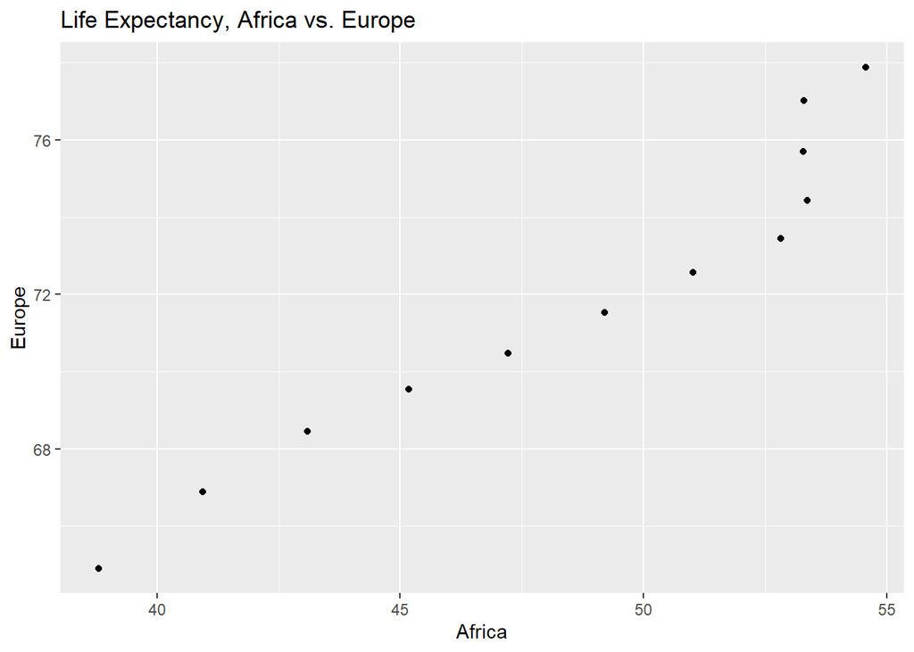

```r
avgContYear %>%
  ggplot(aes(x=Africa, y=Europe)) +
  geom_point() +
  ggtitle("Life Expectancy, Africa vs. Europe")
```

*Re-lengthen the data.*

```r
avgContYear %>%
  pivot_longer(cols= -year,
               names_to="continent",
               values_to="avgLifeExp") %>%
  datatable()
```

|  | year | continent | avgLifeExp |
| --- | --- | --- | --- |
| 1 | 1952 | Africa | 38.7997279750475 |
| 2 | 1952 | Americas | 60.2359897329338 |
| 3 | 1952 | Asia | 42.9411433815645 |
| 4 | 1952 | Europe | 64.9053961792257 |
| 5 | 1952 | Oceania | 69.1704018414364 |
| 6 | 1957 | Africa | 40.9403052180766 |
| 7 | 1957 | Americas | 62.0180618513162 |
| 8 | 1957 | Asia | 47.2883493522573 |
| 9 | 1957 | Europe | 66.8936447278967 |
| 10 | 1957 | Oceania | 70.3169319373946 |

[output cut: 50 more lines]

## Exercise 2: Multivariate Data Reshaping

### Multivariate Option 1

*Make a tibble with one row per year, and columns for life expectancy and GDP per capita (or two other numeric variables) for two or more countries.*

*Re-lengthen the data.*

```r
multiwide <- gapminder %>%
  filter(country %in% c("Burundi", "New Zealand", "Switzerland")) %>%
  pivot_wider(id_cols=year,
              names_from=country,
              values_from=c(lifeExp, pop))

kable(multiwide)
```

| year | lifeExp_Burundi | lifeExp_New Zealand | lifeExp_Switzerland | pop_Burundi | pop_New Zealand | pop_Switzerland |
| --- | --- | --- | --- | --- | --- | --- |
| 1952 | 39.031 | 69.390 | 69.620 | 2445618 | 1994794 | 4815000 |
| 1957 | 40.533 | 70.260 | 70.560 | 2667518 | 2229407 | 5126000 |
| 1962 | 42.045 | 71.240 | 71.320 | 2961915 | 2488550 | 5666000 |
| 1967 | 43.548 | 71.520 | 72.770 | 3330989 | 2728150 | 6063000 |
| 1972 | 44.057 | 71.890 | 73.780 | 3529983 | 2929100 | 6401400 |
| 1977 | 45.910 | 72.220 | 75.390 | 3834415 | 3164900 | 6316424 |
| 1982 | 47.471 | 73.840 | 76.210 | 4580410 | 3210650 | 6468126 |
| 1987 | 48.211 | 74.320 | 77.410 | 5126023 | 3317166 | 6649942 |
| 1992 | 44.736 | 76.330 | 78.030 | 5809236 | 3437674 | 6995447 |
| 1997 | 45.326 | 77.550 | 79.370 | 6121610 | 3676187 | 7193761 |
| 2002 | 47.360 | 79.110 | 80.620 | 7021078 | 3908037 | 7361757 |
| 2007 | 49.580 | 80.204 | 81.701 | 8390505 | 4115771 | 7554661 |

```r
multiwide %>%
  pivot_longer(cols= -year,
               names_to=c(".value", "country"),
               names_sep="_") %>%
  datatable()
```

|  | year | country | lifeExp | pop |
| --- | --- | --- | --- | --- |
| 1 | 1952 | Burundi | 39.031 | 2445618 |
| 2 | 1952 | New Zealand | 69.39 | 1994794 |
| 3 | 1952 | Switzerland | 69.62 | 4815000 |
| 4 | 1957 | Burundi | 40.533 | 2667518 |
| 5 | 1957 | New Zealand | 70.26 | 2229407 |
| 6 | 1957 | Switzerland | 70.56 | 5126000 |
| 7 | 1962 | Burundi | 42.045 | 2961915 |
| 8 | 1962 | New Zealand | 71.24 | 2488550 |
| 9 | 1962 | Switzerland | 71.32 | 5666000 |
| 10 | 1967 | Burundi | 43.548 | 3330989 |

[output cut: 26 more lines]

## Exercise 3: Table Joins (30%)

*Read in the made-up wedding guestlist and email addresses using the following lines:*

```r
suppressMessages(guest <- read_csv("https://raw.githubusercontent.com/STAT545-UBC/Classroom/master/data/wedding/attend.csv"))
suppressMessages(email <- read_csv("https://raw.githubusercontent.com/STAT545-UBC/Classroom/master/data/wedding/emails.csv"))
```

### 3.1

*For each guest in the guestlist (guest tibble), add a column for email address, which can be found in the email tibble.*

```r
email_sep <- email %>%
  separate_rows(guest, sep=", ")

guest %>%
  left_join(email_sep, by=c("name"="guest")) %>%
  datatable()
```

|  | party | name | meal_wedding | meal_brunch | attendance_wedding | attendance_brunch | attendance_golf | email |
| --- | --- | --- | --- | --- | --- | --- | --- | --- |
| 1 | 1 | Sommer Medrano | PENDING | PENDING | PENDING | PENDING | PENDING | sommm@gmail.com |
| 2 | 1 | Phillip Medrano | vegetarian | Menu C | CONFIRMED | CONFIRMED | CONFIRMED | sommm@gmail.com |
| 3 | 1 | Blanka Medrano | chicken | Menu A | CONFIRMED | CONFIRMED | CONFIRMED | sommm@gmail.com |
| 4 | 1 | Emaan Medrano | PENDING | PENDING | PENDING | PENDING | PENDING | sommm@gmail.com |
| 5 | 2 | Blair Park | chicken | Menu C | CONFIRMED | CONFIRMED | CONFIRMED | bpark@gmail.com |
| 6 | 2 | Nigel Webb |  |  | CANCELLED | CANCELLED | CANCELLED | bpark@gmail.com |
| 7 | 3 | Sinead English | PENDING | PENDING | PENDING | PENDING | PENDING | singlish@hotmail.ca |
| 8 | 4 | Ayra Marks | vegetarian | Menu B | PENDING | PENDING | PENDING | marksa42@gmail.com |
| 9 | 5 | Atlanta Connolly | PENDING | PENDING | PENDING | PENDING | PENDING |  |
| 10 | 5 | Denzel Connolly | fish | Menu B | CONFIRMED | CONFIRMED | CONFIRMED |  |

[output cut: 20 more lines]

### 3.2

*Who do we have emails for, yet are not on the guestlist?*

```r
email_sep %>%
  anti_join(guest, by=c("guest"="name")) %>%
  kable()
```

| guest | email |
| --- | --- |
| Turner Jones | tjjones12@hotmail.ca |
| Albert Marshall | themarshallfamily1234@gmail.com |
| Vivian Marshall | themarshallfamily1234@gmail.com |

Turner Jones, Albert Marshall, and Vivian Marshall weren’t invited to the wedding. :(

### 3.3

*Make a guestlist that includes everyone we have emails for (in addition to those on the original guestlist).*

There were three solutions I came up with, based on what data you’d want to keep in the guestlist.

```r
# full dataset, guest + emails like in 3.1
guest %>%
  full_join(email_sep, by=c("name"="guest")) %>%
  datatable()
```

|  | party | name | meal_wedding | meal_brunch | attendance_wedding | attendance_brunch | attendance_golf | email |
| --- | --- | --- | --- | --- | --- | --- | --- | --- |
| 1 | 1 | Sommer Medrano | PENDING | PENDING | PENDING | PENDING | PENDING | sommm@gmail.com |
| 2 | 1 | Phillip Medrano | vegetarian | Menu C | CONFIRMED | CONFIRMED | CONFIRMED | sommm@gmail.com |
| 3 | 1 | Blanka Medrano | chicken | Menu A | CONFIRMED | CONFIRMED | CONFIRMED | sommm@gmail.com |
| 4 | 1 | Emaan Medrano | PENDING | PENDING | PENDING | PENDING | PENDING | sommm@gmail.com |
| 5 | 2 | Blair Park | chicken | Menu C | CONFIRMED | CONFIRMED | CONFIRMED | bpark@gmail.com |
| 6 | 2 | Nigel Webb |  |  | CANCELLED | CANCELLED | CANCELLED | bpark@gmail.com |
| 7 | 3 | Sinead English | PENDING | PENDING | PENDING | PENDING | PENDING | singlish@hotmail.ca |
| 8 | 4 | Ayra Marks | vegetarian | Menu B | PENDING | PENDING | PENDING | marksa42@gmail.com |
| 9 | 5 | Atlanta Connolly | PENDING | PENDING | PENDING | PENDING | PENDING |  |
| 10 | 5 | Denzel Connolly | fish | Menu B | CONFIRMED | CONFIRMED | CONFIRMED |  |

[output cut: 23 more lines]

```r
#same format as guest
guest %>%
  full_join(email_sep %>%
              select(guest)
            , by=c("name"="guest")) %>%
  datatable()
```

|  | party | name | meal_wedding | meal_brunch | attendance_wedding | attendance_brunch | attendance_golf |
| --- | --- | --- | --- | --- | --- | --- | --- |
| 1 | 1 | Sommer Medrano | PENDING | PENDING | PENDING | PENDING | PENDING |
| 2 | 1 | Phillip Medrano | vegetarian | Menu C | CONFIRMED | CONFIRMED | CONFIRMED |
| 3 | 1 | Blanka Medrano | chicken | Menu A | CONFIRMED | CONFIRMED | CONFIRMED |
| 4 | 1 | Emaan Medrano | PENDING | PENDING | PENDING | PENDING | PENDING |
| 5 | 2 | Blair Park | chicken | Menu C | CONFIRMED | CONFIRMED | CONFIRMED |
| 6 | 2 | Nigel Webb |  |  | CANCELLED | CANCELLED | CANCELLED |
| 7 | 3 | Sinead English | PENDING | PENDING | PENDING | PENDING | PENDING |
| 8 | 4 | Ayra Marks | vegetarian | Menu B | PENDING | PENDING | PENDING |
| 9 | 5 | Atlanta Connolly | PENDING | PENDING | PENDING | PENDING | PENDING |
| 10 | 5 | Denzel Connolly | fish | Menu B | CONFIRMED | CONFIRMED | CONFIRMED |

[output cut: 23 more lines]

```r
# only guest names
guest %>%
  select(guest=name) %>%
  union(select(email_sep, guest)) %>%
  datatable()
```

|  | guest |
| --- | --- |
| 1 | Sommer Medrano |
| 2 | Phillip Medrano |
| 3 | Blanka Medrano |
| 4 | Emaan Medrano |
| 5 | Blair Park |
| 6 | Nigel Webb |
| 7 | Sinead English |
| 8 | Ayra Marks |
| 9 | Atlanta Connolly |
| 10 | Denzel Connolly |

[output cut: 23 more lines]